# Data Dive-Summaries

Amritha Prakash

2023-11-26

**Data Set - Sample Super Store :-**

**Points to consider** A numeric summary of data for at least 10 columns of data

- For categorical columns, this should include unique values and counts
- For numeric columns, this includes min/max, central tendency, and some notion of distribution (e.g., quantiles)
- Summaries Combined

A set of at least 5 novel questions to investigate informed by the following:

- column summaries (i.e., the above bullet)
- data documentation
- your project’s goals/purpose

Use of aggregation functions (other than the ones used from the first bullet, above) I.e., use these explore something interesting about your data

A visual summary of at least 5 columns of your data

- This should include distributions at least
- In addition, you should consider trends, correlations, and interactions between variables
- Use different channels (e.g., color) to show how categorical variables interact with continuous variables

Read the Data set

```r
# Load tidyverse
library(tidyverse)
library(dplyr)

Superstore_data=read.csv("SampleSuperstore_final.csv")
head(Superstore_data)
```

```
##        Ship.Mode   Segment       Country            City      State Postal.Code
## 1   Second Class  Consumer United States       Henderson   Kentucky       42420
## 2   Second Class  Consumer United States       Henderson   Kentucky       42420
## 3   Second Class Corporate United States     Los Angeles California       90036
## 4 Standard Class  Consumer United States Fort Lauderdale    Florida       33311
## 5 Standard Class  Consumer United States Fort Lauderdale    Florida       33311
## 6 Standard Class  Consumer United States     Los Angeles California       90032
##   Region        Category Sub.Category    Sales Quantity Discount    Profit
## 1  South       Furniture    Bookcases 261.9600        2     0.00   41.9136
## 2  South       Furniture       Chairs 731.9400        3     0.00  219.5820
## 3   West Office Supplies       Labels  14.6200        2     0.00    6.8714
## 4  South       Furniture       Tables 957.5775        5     0.45 -383.0310
## 5  South Office Supplies      Storage  22.3680        2     0.20    2.5164
## 6   West       Furniture  Furnishings  48.8600        7     0.00   14.1694
```

Various columns within the Data set:-

```r
colnames(Superstore_data)
```

```
##  [1] "Ship.Mode"    "Segment"      "Country"      "City"         "State"
##  [6] "Postal.Code"  "Region"       "Category"     "Sub.Category" "Sales"
## [11] "Quantity"     "Discount"     "Profit"
```

Number of records :-

```r
nrow(Superstore_data)
```

```
## [1] 9994
```

**A numeric summary of data for at least 10 columns of data**

Summarize the Data set - * For categorical columns, this should include unique values and counts

1.Column Ship Mode :-

Unique values for the column - Ship Mode :-

```r
for (x in unique(Superstore_data$Ship.Mode)) {
  print(x)
}
```

```
## [1] "Second Class"
## [1] "Standard Class"
## [1] "First Class"
## [1] "Same Day"
```

Count of Unique Ship Modes :-

```r
n_distinct(Superstore_data$Ship.Mode)
```

```
## [1] 4
```

2.Column Segment :-

Unique values for the column - Segment :-

```r
for (x in unique(Superstore_data$Segment)) {
  print(x)
}
```

```
## [1] "Consumer"
## [1] "Corporate"
## [1] "Home Office"
```

```r
sprintf("Count of the unique Segments: %s", n_distinct(Superstore_data$Segment))
```

```
## [1] "Count of the unique Segments: 3"
```

3.Column Country :-

Unique values for the column - Country

```r
for (x in unique(Superstore_data$Country)) {
  print(x)
}
```

```
## [1] "United States"
```

```r
sprintf("Count of the unique Countries: %s", n_distinct(Superstore_data$Country))
```

```
## [1] "Count of the unique Countries: 1"
```

4.Column City :-

Unique values for the column - City

```r
unique(Superstore_data$City)
```

```
##   [1] "Henderson"         "Los Angeles"       "Fort Lauderdale"
##   [4] "Concord"           "Seattle"           "Fort Worth"
##   [7] "Madison"           "West Jordan"       "San Francisco"
##  [10] "Fremont"           "Philadelphia"      "Orem"
##  [13] "Houston"           "Richardson"        "Naperville"
##  [16] "Melbourne"         "Eagan"             "Westland"
##  [19] "Dover"             "New Albany"        "New York City"
##  [22] "Troy"              "Chicago"           "Gilbert"
##  [25] "Springfield"       "Jackson"           "Memphis"
##  [28] "Decatur"           "Durham"            "Columbia"
##  [31] "Rochester"         "Minneapolis"       "Portland"
##  [34] "Saint Paul"        "Aurora"            "Charlotte"
##  [37] "Orland Park"       "Urbandale"         "Columbus"
##  [40] "Bristol"           "Wilmington"        "Bloomington"
##  [43] "Phoenix"           "Roseville"         "Independence"
```

[output cut: 162 more lines]

```r
sprintf("Count of the unique cities: %s", n_distinct(Superstore_data$City))
```

```
## [1] "Count of the unique cities: 531"
```

5.Column State :-

Unique values for the column - State

```r
unique(Superstore_data$State)
```

```
##  [1] "Kentucky"             "California"           "Florida"
##  [4] "North Carolina"       "Washington"           "Texas"
##  [7] "Wisconsin"            "Utah"                 "Nebraska"
## [10] "Pennsylvania"         "Illinois"             "Minnesota"
## [13] "Michigan"             "Delaware"             "Indiana"
## [16] "New York"             "Arizona"              "Virginia"
## [19] "Tennessee"            "Alabama"              "South Carolina"
## [22] "Oregon"               "Colorado"             "Iowa"
## [25] "Ohio"                 "Missouri"             "Oklahoma"
## [28] "New Mexico"           "Louisiana"            "Connecticut"
## [31] "New Jersey"           "Massachusetts"        "Georgia"
## [34] "Nevada"               "Rhode Island"         "Mississippi"
## [37] "Arkansas"             "Montana"              "New Hampshire"
## [40] "Maryland"             "District of Columbia" "Kansas"
## [43] "Vermont"              "Maine"                "South Dakota"
## [46] "Idaho"                "North Dakota"         "Wyoming"
## [49] "West Virginia"
```

```r
sprintf("Count of the unique States: %s", n_distinct(Superstore_data$State))
```

```
## [1] "Count of the unique States: 49"
```

6.Column Region :

Unique values for the column - Region

```r
for (x in unique(Superstore_data$Region)) {
  print(x)
}
```

```
## [1] "South"
## [1] "West"
## [1] "Central"
## [1] "East"
```

```r
sprintf("Count of the unique Regions: %s", n_distinct(Superstore_data$Region))
```

```
## [1] "Count of the unique Regions: 4"
```

7.Column Category :-

Unique values for the column - Category

```r
for (x in unique(Superstore_data$Category)) {
  print(x)
}
```

```
## [1] "Furniture"
## [1] "Office Supplies"
## [1] "Technology"
```

```r
sprintf("Count of the unique Categories: %s", n_distinct(Superstore_data$Category))
```

```
## [1] "Count of the unique Categories: 3"
```

8.Sub-Category :-

Unique values for the column - Sub-category

```r
sprintf("Unique values for the column - Sub-Category :");
```

```
## [1] "Unique values for the column - Sub-Category :"
```

```r
for (x in unique(Superstore_data$Sub.Category)) {
  print(x)
}
```

```
## [1] "Bookcases"
## [1] "Chairs"
## [1] "Labels"
## [1] "Tables"
## [1] "Storage"
## [1] "Furnishings"
## [1] "Art"
## [1] "Phones"
## [1] "Binders"
## [1] "Appliances"
## [1] "Paper"
## [1] "Accessories"
## [1] "Envelopes"
## [1] "Fasteners"
## [1] "Supplies"
## [1] "Machines"
## [1] "Copiers"
```

```r
sprintf("Count of the Sub-Category: %s", n_distinct(Superstore_data$Sub.Category))
```

```
## [1] "Count of the Sub-Category: 17"
```

9.Postal Code :-

Even though Postal code is numeric in nature, it doesn’t have any value as the mean of a postal code wouldn’t make sense. Hence considering it as a Categorical value.

Unique values for the column - Postal code :

```r
unique(Superstore_data$Postal.Code)
```

```
##   [1] 42420 90036 33311 90032 28027 98103 76106 53711 84084 94109 68025 19140
##  [13] 84057 90049 77095 75080 77041 60540 32935 55122 48185 19901 47150 10024
##  [25] 12180 90004 60610 85234 22153 10009 49201 38109 77070 35601 94122 27707
##  [37] 60623 29203 55901 55407 97206 55106 80013 28205 60462 10035 50322 43229
##  [49] 37620 19805 61701 85023 95661 64055 91104 43055 53132 85254 95123 98105
##  [61] 98115 73034 90045 19134 88220 78207 77036 62521 71203  6824 75051 92374
##  [73] 45011  7090 19120 44312 80219 75220 37064 90604 48601 44256 43017 48227
##  [85] 38401 33614 95051 55044 92037 77506 94513 27514  7960 45231 94110 90301
##  [97] 33319 80906  7109 48180  8701 22204 80004  7601 33710 19143 90805 92345
## [109] 37130 84041 78745  1852 31907  6040 78550 85705 62301  2038 33024 98198
## [121] 61604 89115  2886 33180 28403 92646 40475 80027  1841 39212 48187 10801
## [133] 28052 32216 47201 13021 73071 94521 60068 79109 11757 90008 92024 77340
## [145] 14609 72701 92627 80134 30318 64118 59405 48234 33801 36116 85204 60653
## [157] 54302 45503 92804 98270 97301 78041 75217 43123 10011 48126 31088 94591
## [169] 92691 48307  7060 85635 98661 60505 76017 40214 75081 44105 75701 27217
```

[output cut: 38 more lines]

```r
sprintf("Count of the Postal-Code: %s",n_distinct(Superstore_data$Postal.Code))
```

```
## [1] "Count of the Postal-Code: 631"
```

- For numeric columns, this includes min/max, central tendency, and some notion of distribution (e.g., quantiles)
10. Sales :-

```r
summary(Superstore_data$Sales)
```

```
##      Min.   1st Qu.    Median      Mean   3rd Qu.      Max.
##     0.444    17.280    54.490   229.858   209.940 22638.480
```

11. Quantity :-

```r
summary(Superstore_data$Quantity)
```

```
##    Min. 1st Qu.  Median    Mean 3rd Qu.    Max.
##    1.00    2.00    3.00    3.79    5.00   14.00
```

12.Discount :-

```r
summary(Superstore_data$Discount)
```

```
##    Min. 1st Qu.  Median    Mean 3rd Qu.    Max.
##  0.0000  0.0000  0.2000  0.1562  0.2000  0.8000
```

13. Profit :-

```r
summary(Superstore_data$Profit)
```

```
##      Min.   1st Qu.    Median      Mean   3rd Qu.      Max.
## -6599.978     1.729     8.666    28.657    29.364  8399.976
```

- Summaries Combined :

```r
summary(Superstore_data)
```

```
##   Ship.Mode           Segment            Country              City
##  Length:9994        Length:9994        Length:9994        Length:9994
##  Class :character   Class :character   Class :character   Class :character
##  Mode  :character   Mode  :character   Mode  :character   Mode  :character
##
##
##
##     State            Postal.Code       Region            Category
##  Length:9994        Min.   : 1040   Length:9994        Length:9994
##  Class :character   1st Qu.:23223   Class :character   Class :character
##  Mode  :character   Median :56431   Mode  :character   Mode  :character
##                     Mean   :55190
##                     3rd Qu.:90008
##                     Max.   :99301
##  Sub.Category           Sales              Quantity        Discount
##  Length:9994        Min.   :    0.444   Min.   : 1.00   Min.   :0.0000
##  Class :character   1st Qu.:   17.280   1st Qu.: 2.00   1st Qu.:0.0000
##  Mode  :character   Median :   54.490   Median : 3.00   Median :0.2000
##                     Mean   :  229.858   Mean   : 3.79   Mean   :0.1562
##                     3rd Qu.:  209.940   3rd Qu.: 5.00   3rd Qu.:0.2000
##                     Max.   :22638.480   Max.   :14.00   Max.   :0.8000
##      Profit
##  Min.   :-6599.978
##  1st Qu.:    1.729
##  Median :    8.666
##  Mean   :   28.657
##  3rd Qu.:   29.364
##  Max.   : 8399.976
```

- Distinct Count of each column -

```r
sapply(Superstore_data,function(x) n_distinct(x))
```

```
##    Ship.Mode      Segment      Country         City        State  Postal.Code
##            4            3            1          531           49          631
##       Region     Category Sub.Category        Sales     Quantity     Discount
##            4            3           17         5825           14           12
##       Profit
##         7287
```

#**Data Documentation:**

1. There are 9994 rows.
2. The Data is tidy with about 13 columns, Each row represents a unique and separate observation.
3. It fulfills the criteria of atleast 2 columns being continuous. In my case the columns Sales(Price), Profit and Discount are Decimal Also, Profit is having both positive and negative values. Negative values are indicating Loss.  
   *Sales* having a range of $0.444 to $22638.480  
   *Profit* having a range starting from $-6599.978 to $8399.976  
   *Discount* having a range from 0 to 0.8  
   *Quantity* is numeric with a range starting from 1 to 14.
4. It also fulfills the criteria of atleast 2 columns being categorical. In my case there are 9 categorical columns which are - Ship Mode, Segment, Country, City, State, Postal Code, Region, Category, Sub.Category  
   (Here, considering Postal Code as Categorical as the numeric in the value does not have any significance.)

**Purpose of Data Collection**:- To figure out the profit earned by the Superstore via its sales in various parts of USA. Further, it can be used to find trends in the same and come up with improvements.

Explanantion of each Columns :

1. Ship Mode - It has 4 values, they are First Class, Same Day, Second Class and Standard Class. Each value is defines the limit for being delayed as follows: -  
   Same day: >=0 days  
   First class: >=2 days  
   Second class: >=3 days  
   Standard class: >= 5 days
2. Segment - It is the product sector.There are segments which are Consumer, Corporate and Home Office
3. Country - This column contains the country details. It was found to be only for United States i.e one value. Hence this column can be removed.
4. City - Various Cities present in United States.There are about 531 cities.
5. State - There are 49 states in this dataset.
6. Postal Code - There are 631 postal codes in this dataset
7. Region - There are 4 regions in the dataset. i.e. South, West, Central and East
8. Category - There are 3 categories, they are Furniture, Office Supplies and Technology.
9. Sub-Category - There are 17 sub-categories, some of them are - Bookcases, Chairs, Labels, Tables, Storage, Furnishings, Art, Phones, Binders, Appliances, Paper, Accessories, Envelopes, Fasteners, Supplies, Machines, Copiers
10. Sales - It is the price. Having a range starting from $0.444 to $22638.480
11. Profit - It is the profit earned from the product. Can also indicate loss with a negative sign. Having a range -6599.978 to 8399.976
12. Discount - Discount given for the product purchased, range starts from 0 to 0.8.
13. Quantity - The quantity of products bought, range starts from 1 to 14.

In order to understand the data better we can try to visualize the data, which will indirectly help us in asking valid questions to investigate further.

**visual summary**

- Univariate Plot:-

1.Ship Mode -

From the plot, can observe that most purchases are done via Ship.Mode = Standard Class, followed by Second Class, First Class and Same Day. About 6000 records out of 9994 i.e. more than 50% purchase are via Standard Class ship mode.

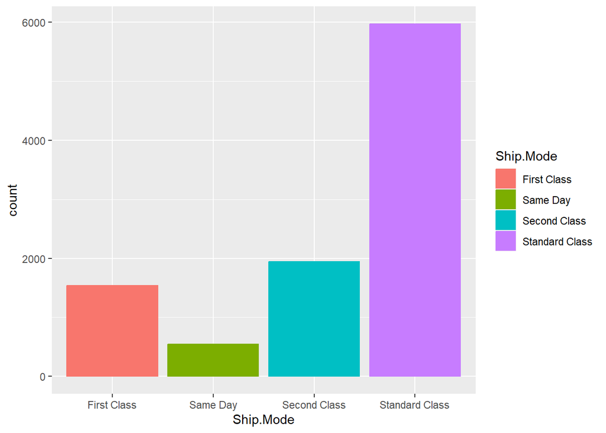

```r
Superstore_data |>
  ggplot(mapping = aes(x=Ship.Mode, color = Ship.Mode, fill=Ship.Mode)) +
  geom_bar()
```

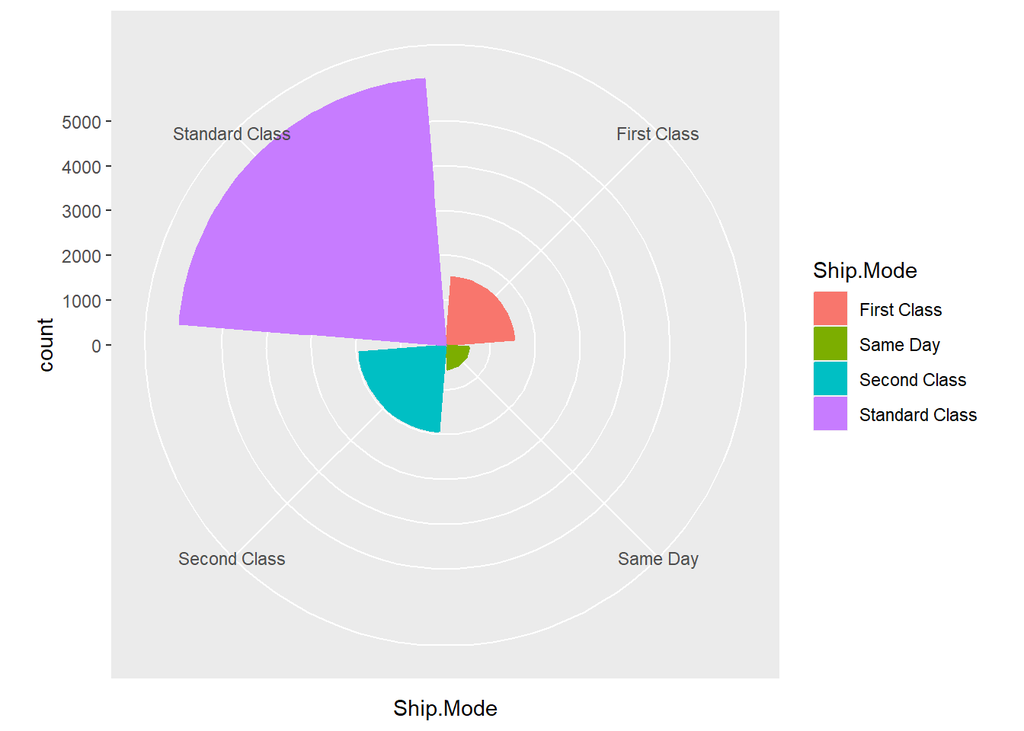

```r
last_plot() +
  coord_polar()
```

2.Segment -

From the plot below can figure out that most purchases are done for Consumer needs, which are greater than 5000 purchases.Followed by Corporate purchases which is around 3000 and Home Office with a count around 1800.

So most purchases in the Superstore are done by the Consumer segment.

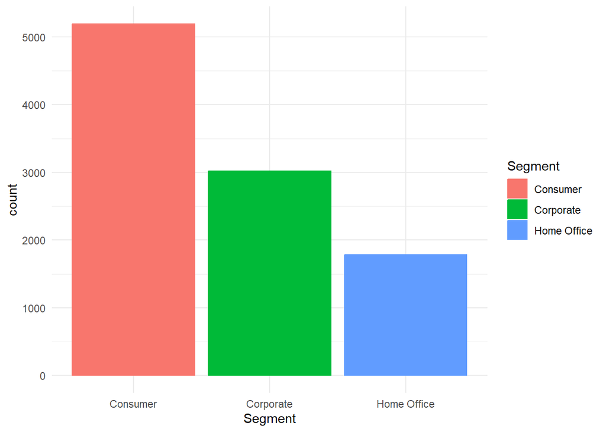

```r
Superstore_data |>
  ggplot(mapping = aes(x=Segment, color = Segment, fill=Segment)) +
  geom_bar() +
  theme_minimal()
```

3.Region -

Overall every region has bought products but from the plot below we can observe that customers from West and East part have purchased most products, when compared to Central and southern part of US.

It answers the question -> which region has purchased the most products?

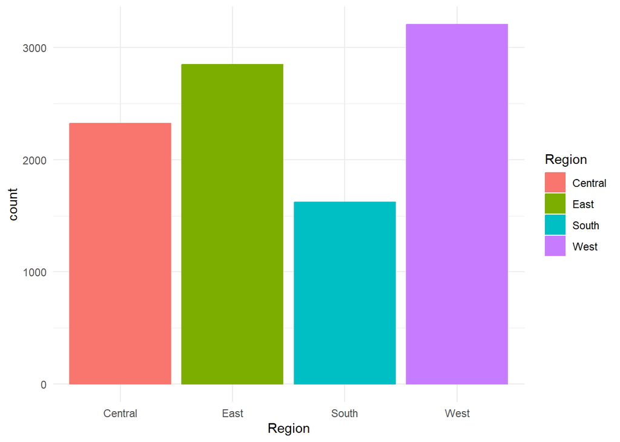

```r
Superstore_data |>
  ggplot(mapping = aes(x=Region, color = Region, fill=Region)) +
  geom_bar() +
  theme_minimal()
```

4.State -

As it was seen above, there are about 49 states, plotting them all to understand the count of purchase is pretty difficult. Hence narrowing it down to top 10 states.

It would answer the question -> which are the top 10 states that have purchased the products from the Superstore?

```r
state_count<- aggregate(Superstore_data$State,by=list(Superstore_data$State), FUN=length)

top_10_states_count <-state_count %>%
arrange(desc(x)) %>%
    slice(1:10) %>%
  rename (
    state=Group.1,
    count=x
  )
top_10_states_count
```

```
##             state count
## 1      California  2001
## 2        New York  1128
## 3           Texas   985
## 4    Pennsylvania   587
## 5      Washington   506
## 6        Illinois   492
## 7            Ohio   469
## 8         Florida   383
## 9        Michigan   255
## 10 North Carolina   249
```

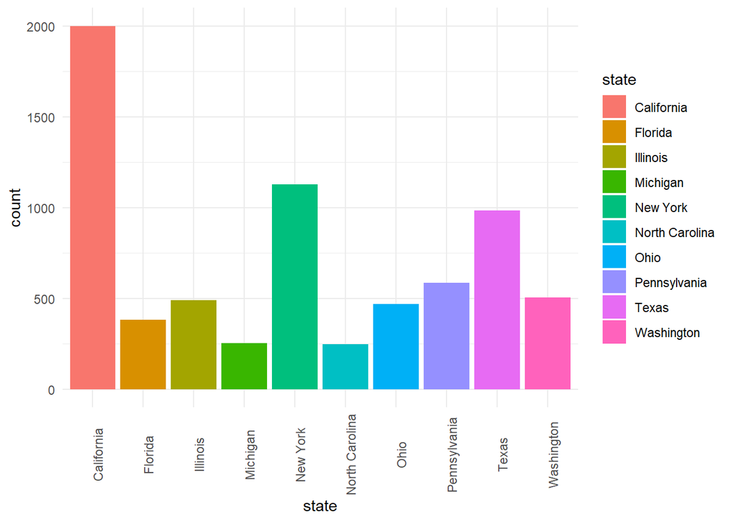

```r
top_10_states_count |>
  ggplot(mapping = aes(x=state, y=count, fill=state)) +
  geom_bar(stat = "identity") +
  theme_minimal()+
   theme (axis.text.x =  element_text(angle=90))
```

Can see that California is the state that has the most purchases.

5.City - As West region had most purchases of product, we can verify that by digging deep into the cities. Also there are about 531 city. Drilling down and figuring out the top 10 cities.

It would answer the question -> which are the top 10 cities that purchased the products from the Superstore?

```r
City_count<- aggregate(Superstore_data$City,by=list(Superstore_data$City), FUN=length)

top_10_city_count <-City_count %>%
arrange(desc(x)) %>%
    slice(1:10) %>%
  rename (
    City=Group.1,
    Count=x
  )
top_10_city_count
```

```
##             City Count
## 1  New York City   915
## 2    Los Angeles   747
## 3   Philadelphia   537
## 4  San Francisco   510
## 5        Seattle   428
## 6        Houston   377
## 7        Chicago   314
## 8       Columbus   222
## 9      San Diego   170
## 10   Springfield   163
```

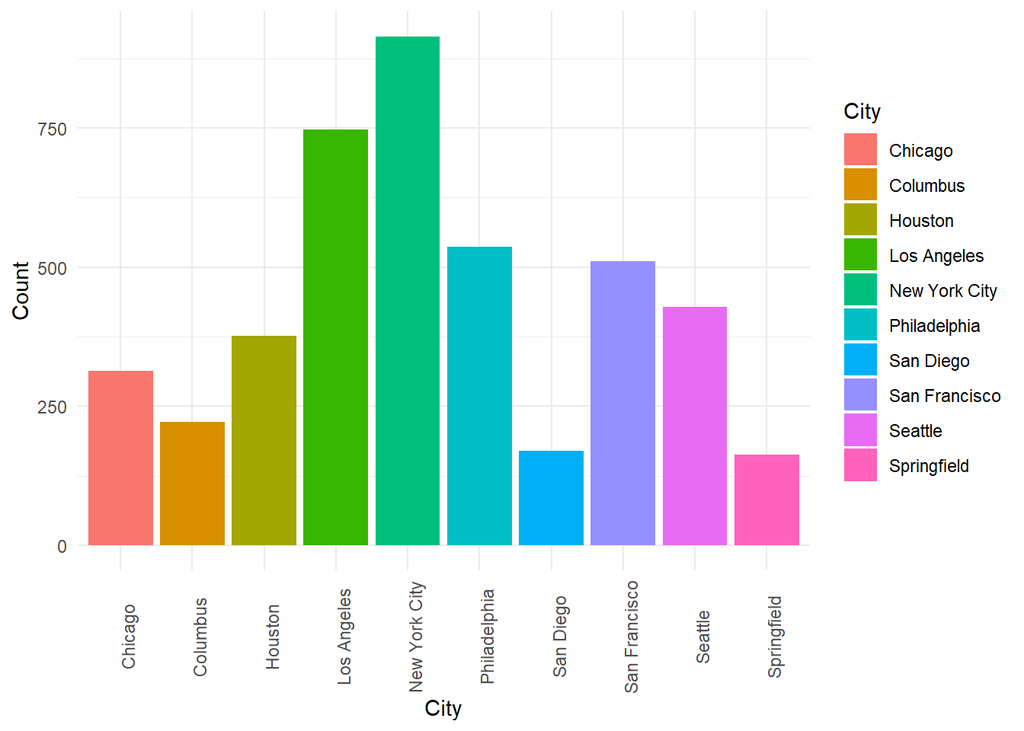

```r
top_10_city_count |>
  ggplot(mapping = aes(x=City, y=Count, fill=City)) +
  geom_bar(stat = "identity") +
  theme_minimal()+
   theme (axis.text.x =  element_text(angle=90))
```

6.Category - From the plot below can figure out that Office supplies were the products which were bought the most, in all the purchases.

It answers the question -> which category of products were bought the most?

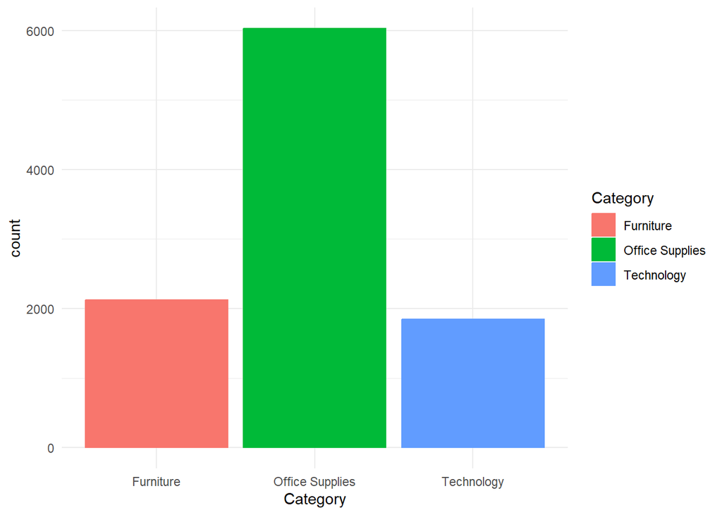

```r
Superstore_data |>
  ggplot(mapping = aes(x=Category, color = Category, fill=Category)) +
  geom_bar() +
  theme_minimal()
```

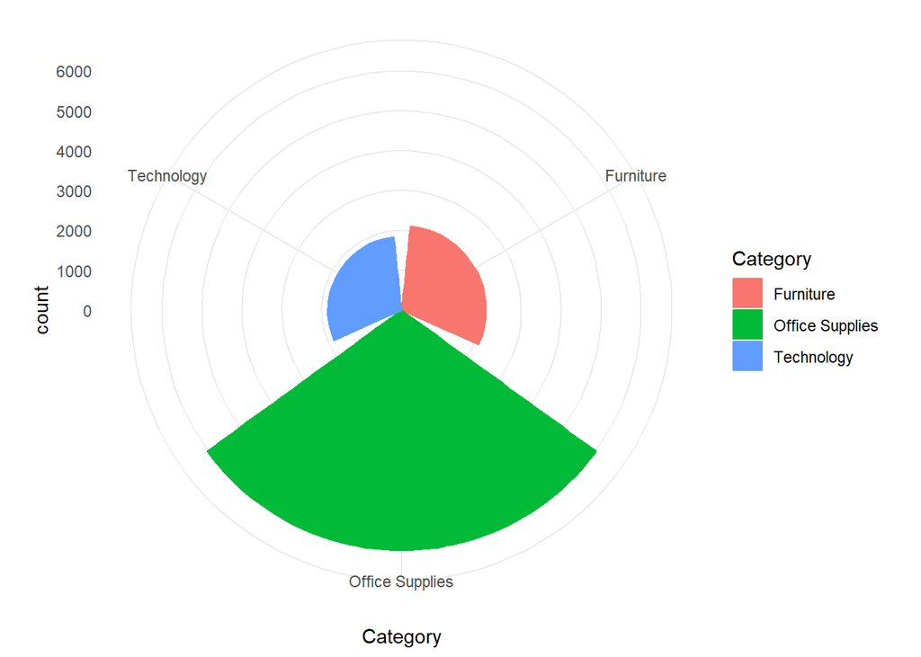

```r
last_plot() +
  coord_polar()
```

7.Sub - Category :- From the previous plot, we had observed that Office Supplies were the most purchased category. In order to understand which item from those Office supplies are being bought the most, we plot the sub-category. In the plot below, we can see that Binders are the heavily purchased item, followed by Paper and Furnishings.

It answers the question -> which sub-category of products were bought the most?

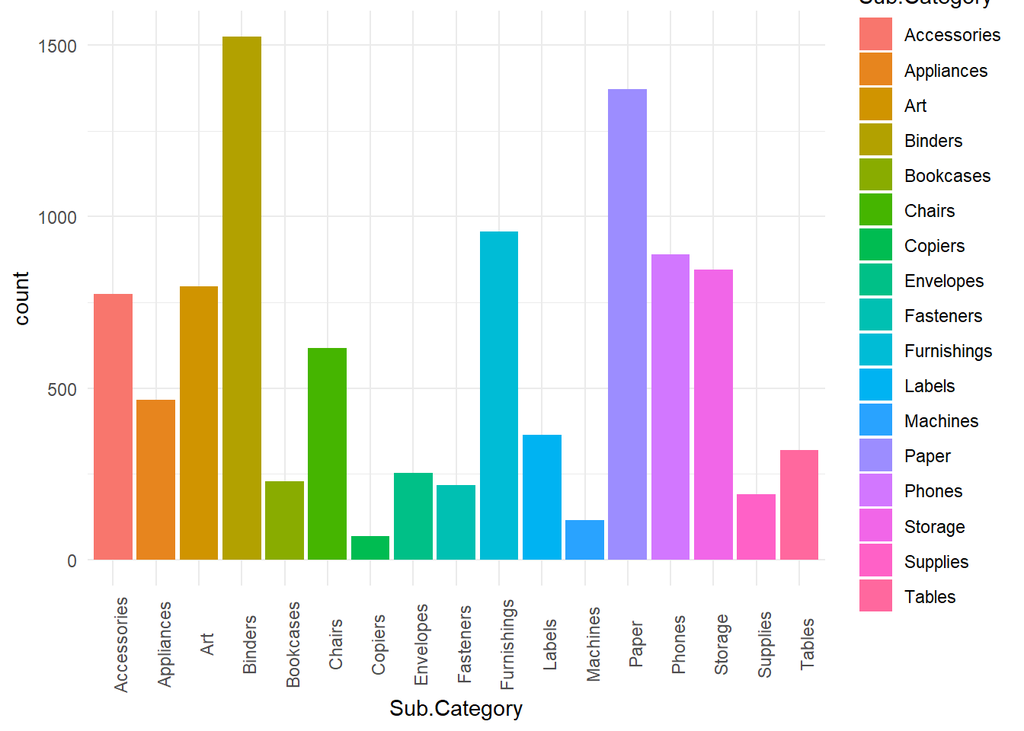

```r
Superstore_data |>
  ggplot(mapping = aes(x=Sub.Category, fill=Sub.Category)) +
  geom_bar() +
  theme_minimal() +
   theme (axis.text.x =  element_text(angle=90))
```

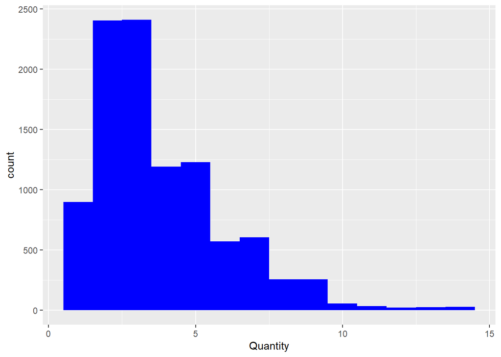

```r
Superstore_data %>%
ggplot() +
geom_histogram(mapping = aes(x = Quantity), fill = 'blue', binwidth=1)
```

Multivariate plotting-

1.Region vs Category :

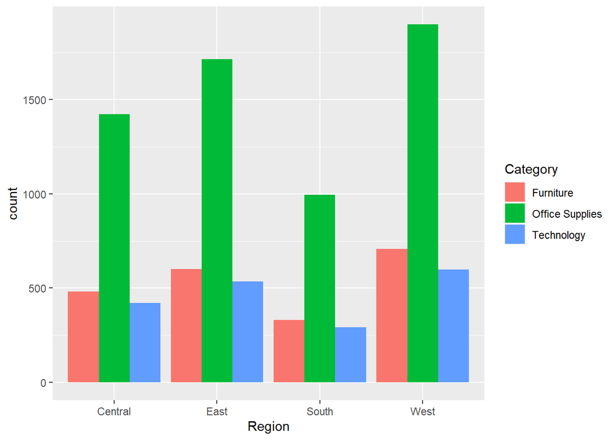

```r
Superstore_data %>%
ggplot() +
  geom_bar(mapping = aes(x = Region, fill = Category), position="dodge")
```

Be it any region, all of them have a common category which was purchased the most i.e. Office Supplies While Furniture and Tech were bought little less.

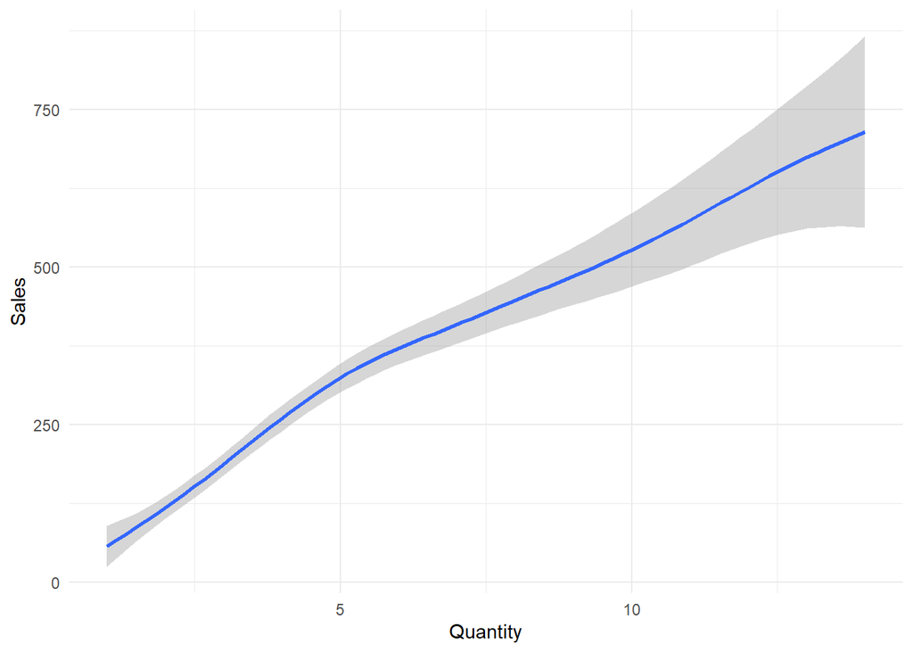

```r
Superstore_data %>%
ggplot() +
  geom_smooth(mapping = aes(x = Quantity, y = Sales))+
  theme_minimal()
```

We can see the Sales and Quantity have a Positive Correlation. As the quantity increases the sales also increases.

3.Sub-Category and Mean Sales -

```r
aggregate(Superstore_data$Sales, list(Superstore_data$Sub.Category), FUN=mean) |>
  rename (
    Sub_Category=Group.1,
    Mean_Sales=x
  ) |>
arrange(desc(Mean_Sales))
```

```
##    Sub_Category Mean_Sales
## 1       Copiers 2198.94162
## 2      Machines 1645.55331
## 3        Tables  648.79477
## 4        Chairs  532.33242
## 5     Bookcases  503.85963
## 6        Phones  371.21153
## 7       Storage  264.59055
## 8      Supplies  245.65020
## 9    Appliances  230.75571
## 10  Accessories  215.97460
## 11      Binders  133.56056
## 12  Furnishings   95.82567
## 13    Envelopes   64.86772
## 14        Paper   57.28409
## 15       Labels   34.30305
## 16          Art   34.06883
## 17    Fasteners   13.93677
```

Even though from uni-variate visualization we found that people bought binders and papers. The most costliest item from all of those was a Copier followed by Machines.

4.Region vs Category vs Sales:

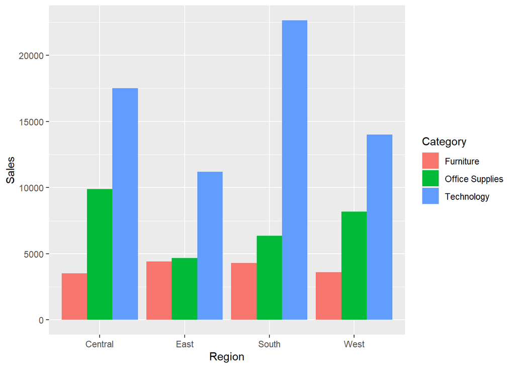

```r
Superstore_data %>%
ggplot() +
  geom_bar(mapping = aes(x = Region, y=Sales,fill = Category),stat = "identity", position="dodge")
```

5.Region vs Category vs Profit:

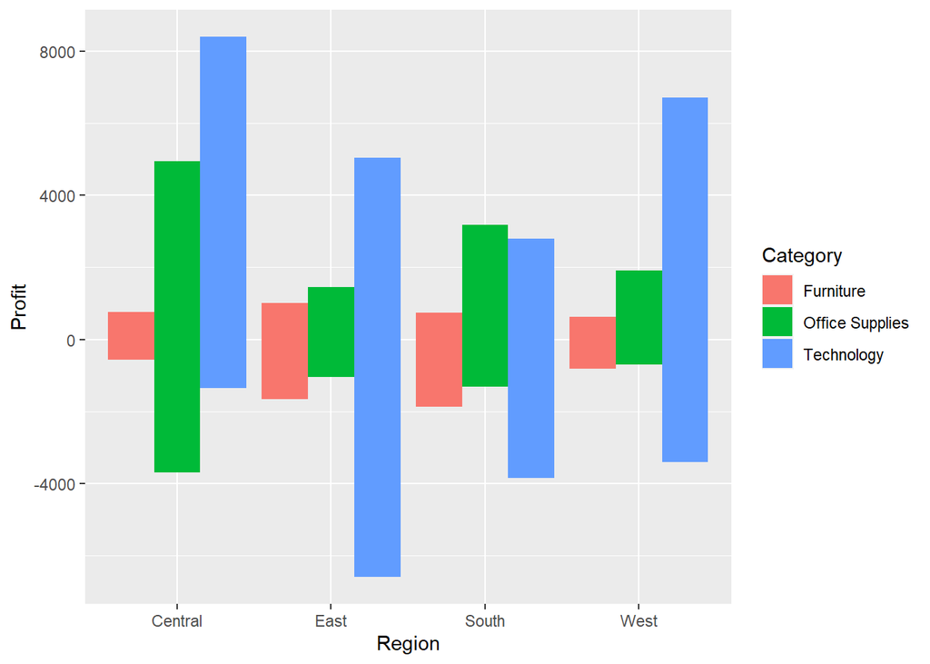

```r
Superstore_data %>%
ggplot() +
  geom_bar(mapping = aes(x = Region, y=Profit,fill = Category),stat = "identity", position="dodge")
```